# Time spent outside and inside the rooms

# 1 Overview

This sheet examines how much time that the participants spent on the pathway outside the rooms and collecting objects inside the rooms. It will also examine the relationships between the length of the time and the reported curiosity level on the room.

# 2 Outside the rooms

## 2.1 Some basic descriptive stats

### 2.1.1 How many participants included in total?

There are a total of 42 participants who had a record of time spent on the pathway outside the rooms. Among them, 27 are from the *Immediate* condition, and 15 from the *Delayed* condition.

### 2.1.2 How long is the maximal and minimal length of time spent outside the rooms?

The longest time spent outside the rooms is 71.1s, and the shortest is 13.9s. On average each participant spent 27.8s on the pathway.

## 2.2 Is the time length correlated with curiosity level?

I was thinking there should be a negative correlation because the more curious the P felt about the room the more eager he/she would want to enter the room and thus shorter time on the pathway outside the room.

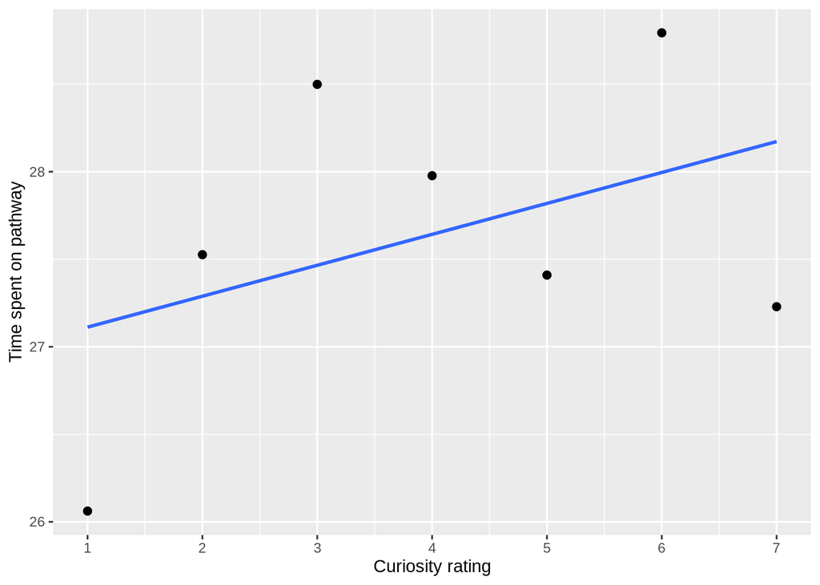

```r
baseline <- lme(Duration ~ 1, random = ~ 1|SubjectNo, data = outside.per.room, method = "ML", na.action = na.exclude)

cur.intercept <- update(baseline, .~. + CurRating)
cur.slope     <- update(cur.intercept, random = ~ 1+CurRating|SubjectNo)

anova(baseline, cur.intercept, cur.slope)
```

```
##               Model df      AIC      BIC    logLik   Test   L.Ratio p-value
## baseline          1  3 1513.835 1524.387 -753.9175
## cur.intercept     2  4 1514.448 1528.518 -753.2239 1 vs 2 1.3872349  0.2389
## cur.slope         3  6 1518.448 1539.553 -753.2239 2 vs 3 0.0000002  1.0000
```

```r
summary(cur.intercept)$tTable
```

```
##                 Value Std.Error  DF   t-value      p-value
## (Intercept) 27.137540 0.9361744 206 28.987696 1.247063e-74
## CurRating    0.161958 0.1378438 206  1.174939 2.413756e-01
```

## 2.3 Are there any relationships between *Novelty* and time length outside the rooms?

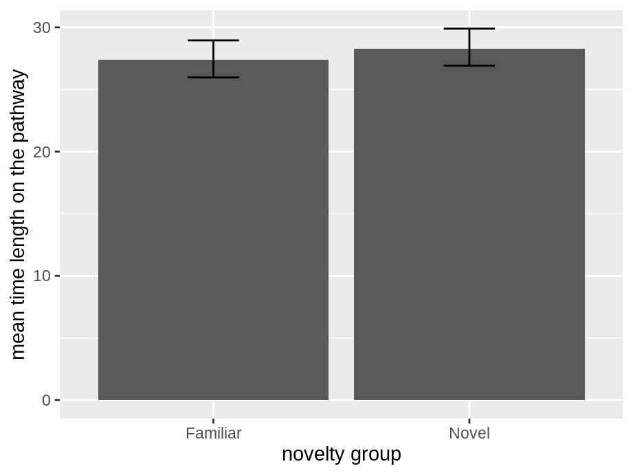

```r
t.test(meanDur~Group, data = outside.novelty, paired = TRUE)
```

```
##
##  Paired t-test
##
## data:  meanDur by Group
## t = -2.4284, df = 41, p-value = 0.01964
## alternative hypothesis: true difference in means is not equal to 0
## 95 percent confidence interval:
##  -1.5847338 -0.1456589
## sample estimates:
## mean of the differences
##              -0.8651964
```

## 2.4 Put *novelty* and *curiosity* together?

```r
n.intercept  <- update(cur.intercept, .~. + Group)
n.slope      <- update(n.intercept, .~. + Group : CurRating)

anova(baseline, cur.intercept, n.intercept, n.slope)
```

```
##               Model df      AIC      BIC    logLik   Test  L.Ratio p-value
## baseline          1  3 1513.835 1524.387 -753.9175
## cur.intercept     2  4 1514.448 1528.518 -753.2239 1 vs 2 1.387235  0.2389
## n.intercept       3  5 1515.102 1532.689 -752.5510 2 vs 3 1.345785  0.2460
## n.slope           4  6 1513.922 1535.027 -750.9612 3 vs 4 3.179720  0.0746
```

# 3 Inside the rooms

It is reasonable to think that the more curious the participants feel about the room, the longer they tend to stay in the room, probably exploring. However, in this study, they were asked to find boxes and collect objects in each room. Therefore, the time they spent in each room was determined by how quickly they could locate the boxes rather than how curious they felt about the room.

Having that said, it is likely that being curious may interfere their search for boxes. There may be a very subtle effect that the more curious the longer they stayed because they would need more time to find the boxes because they were distracted by the room details.

So let’s see how it looks.

## 3.1 Some basic descriptive stats

### 3.1.1 How many participants included in total?

There are a total of 42 participants who had a record of time spent on the pathway inside the rooms. Among them, 27 are from the *Immediate* condition, and 15 from the *Delayed* condition.

### 3.1.2 How long is the maximal and minimal length of time spent inside the rooms?

The longest time spent inside the rooms is 242.1s, and the shortest is 47.3s. On average each participant spent 96.4s on the pathway.

## 3.2 Is the time length correlated with curiosity level?

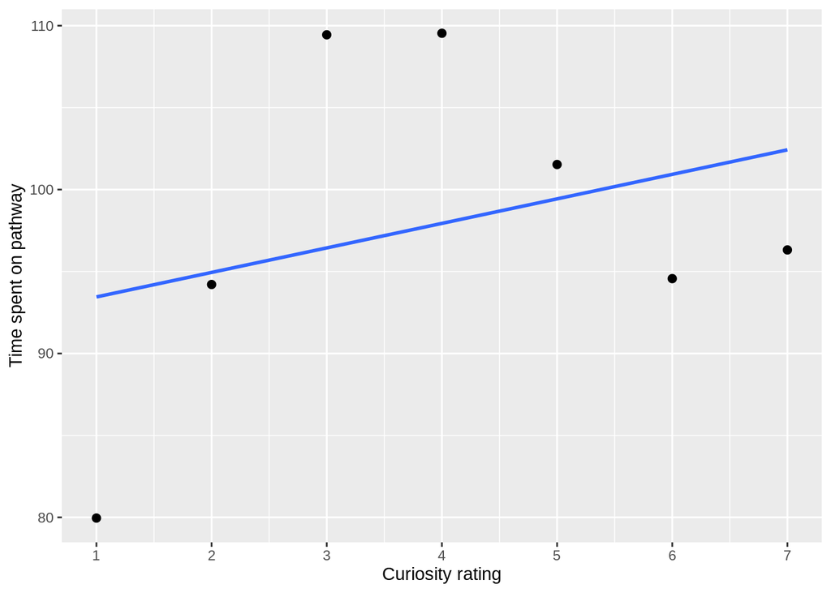

```r
baseline <- lme(Duration ~ 1, random = ~ 1|SubjectNo, data = inside.per.room, method = "ML", na.action = na.exclude)

cur.intercept <- update(baseline, .~. + CurRating)
cur.slope     <- update(cur.intercept, random = ~ 1+CurRating|SubjectNo)

anova(baseline, cur.intercept, cur.slope)
```

```
##               Model df      AIC      BIC    logLik   Test   L.Ratio p-value
## baseline          1  3 2351.978 2362.344 -1172.989
## cur.intercept     2  4 2352.494 2366.316 -1172.247 1 vs 2 1.4833671  0.2232
## cur.slope         3  6 2356.494 2377.226 -1172.247 2 vs 3 0.0000001  1.0000
```

Ok, a positive trend but not significant.

I forgot about another possibility of spending more time in the *novel* rooms as compared to *familair* rooms - because they had visited the *familiar* rooms and explored their layout, it would be easier for them to find the boxes in the *familiar* rooms than in the *novel* rooms.

So there are several things interwined behind the positive trend.

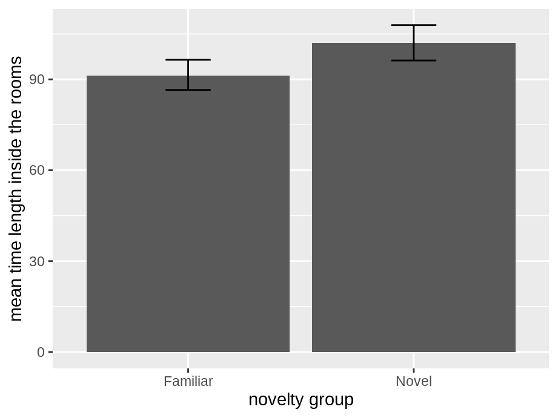

```r
t.test(meanDur~Group, data = inside.novelty[SubjectNo != "P52"], paired = TRUE)
```

```
##
##  Paired t-test
##
## data:  meanDur by Group
## t = -2.7306, df = 40, p-value = 0.009358
## alternative hypothesis: true difference in means is not equal to 0
## 95 percent confidence interval:
##  -18.479760  -2.759337
## sample estimates:
## mean of the differences
##               -10.61955
```

# 4 Can the time length predict the performance on the recall test?

## 4.1 Immediate version

### 4.1.1 Outside the rooms

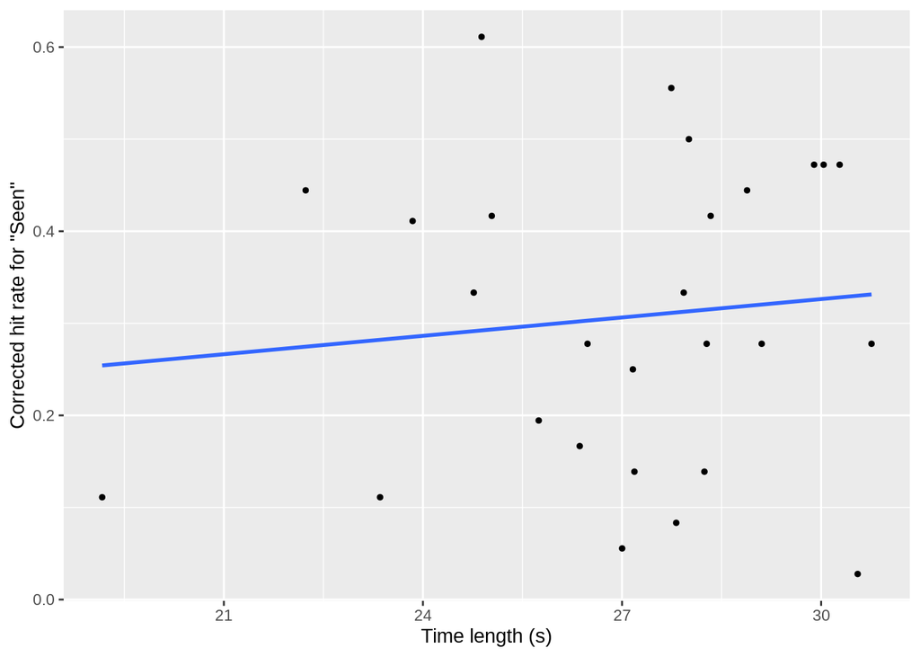

```r
baseline <- lme(SAcc ~ 1, random = ~ 1|SubjectNo, data = outside.per.room[Version == "Immediate"], method = "ML", na.action = na.exclude)

t.intercept <- update(baseline, .~. + Duration)
t.slope     <- update(t.intercept, random = ~ 1 + Duration|SubjectNo)

anova(baseline, t.intercept, t.slope)
```

```
##             Model df      AIC      BIC     logLik   Test  L.Ratio p-value
## baseline        1  3 7.804073 17.04829 -0.9020366
## t.intercept     2  4 4.070014 16.39563  1.9649928 1 vs 2 5.734059  0.0166
## t.slope         3  6 7.928203 26.41663  2.0358984 2 vs 3 0.141811  0.9315
```

```r
summary(t.slope)$tTable
```

```
##                   Value   Std.Error  DF    t-value    p-value
## (Intercept) -0.02418525 0.157331778 133 -0.1537213 0.87806247
## Duration     0.01221814 0.005600594 133  2.1815796 0.03089802
```

Ok, the longer they spent on the pathway, the better they could recall the objects. Not surprising, but it just added another factor contributing to the memory enhancement.

#### 4.1.1.1 What about source memory?

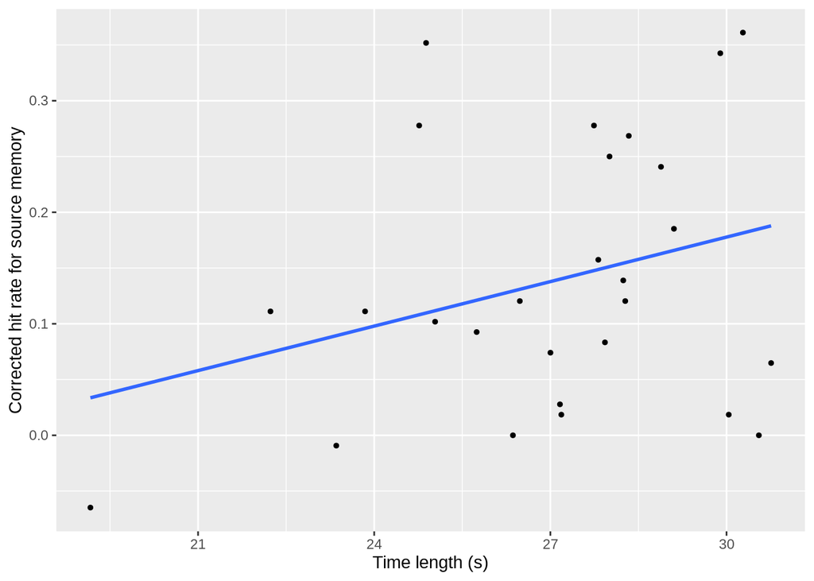

An even stronger trend here.

```
##             Model df       AIC       BIC   logLik   Test  L.Ratio p-value
## baseline        1  3 -46.42906 -37.18485 26.21453
## t.intercept     2  4 -55.71351 -43.38789 31.85675 1 vs 2 11.28444  0.0008
## t.slope         3  6 -53.73300 -35.24457 32.86650 2 vs 3  2.01949  0.3643
```

```
##                   Value   Std.Error  DF   t-value      p-value
## (Intercept) -0.28705972 0.116365789 133 -2.466874 0.0149012408
## Duration     0.01574854 0.004385011 133  3.591449 0.0004615534
```

Same!

### 4.1.2 Inside the rooms

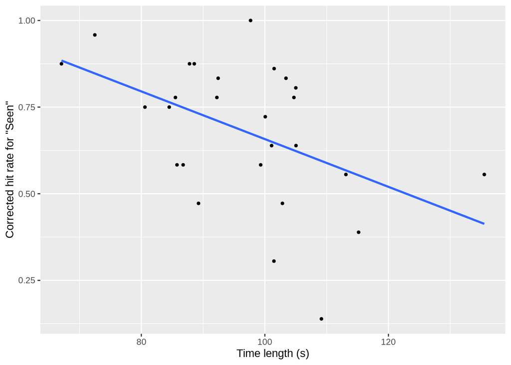

Haha, there is a negative trend!!

```r
baseline <- lme(SAcc ~ 1, random = ~ 1|SubjectNo, data = inside.per.room[Version == "Immediate"], method = "ML", control = list(msMaxIter = 500, opt = "optim", msVerbose=FALSE), na.action = na.exclude)

t.intercept <- update(baseline, .~. + Duration)
t.slope     <- update(t.intercept, random = ~ 1 + Duration|SubjectNo)

anova(baseline, t.intercept, t.slope)
```

```
##             Model df       AIC       BIC   logLik   Test  L.Ratio p-value
## baseline        1  3 -50.43350 -41.38166 28.21675
## t.intercept     2  4 -48.49827 -36.42915 28.24913 1 vs 2 0.064771  0.7991
## t.slope         3  6 -52.96509 -34.86141 32.48254 2 vs 3 8.466824  0.0145
```

Looks like there is a large variance among participants.

```r
summary(t.slope)
```

```
## Linear mixed-effects model fit by maximum likelihood
##  Data: inside.per.room[Version == "Immediate"]
##         AIC       BIC   logLik
##   -52.96509 -34.86141 32.48254
##
## Random effects:
##  Formula: ~1 + Duration | SubjectNo
##  Structure: General positive-definite, Log-Cholesky parametrization
##             StdDev      Corr
## (Intercept) 0.326090848 (Intr)
## Duration    0.001447739 -0.962
## Residual    0.157752910
##
## Fixed effects: SAcc ~ Duration
##                  Value  Std.Error  DF   t-value p-value
## (Intercept)  0.6794394 0.07555747 123  8.992352  0.0000
## Duration    -0.0000715 0.00049210 123 -0.145374  0.8847
##  Correlation:
##          (Intr)
## Duration -0.886
##
## Standardized Within-Group Residuals:
##         Min          Q1         Med          Q3         Max
## -2.80437207 -0.59691907  0.08164906  0.52577682  2.39915862
##
## Number of Observations: 151
## Number of Groups: 27
```

#### 4.1.2.1 What about source memory?

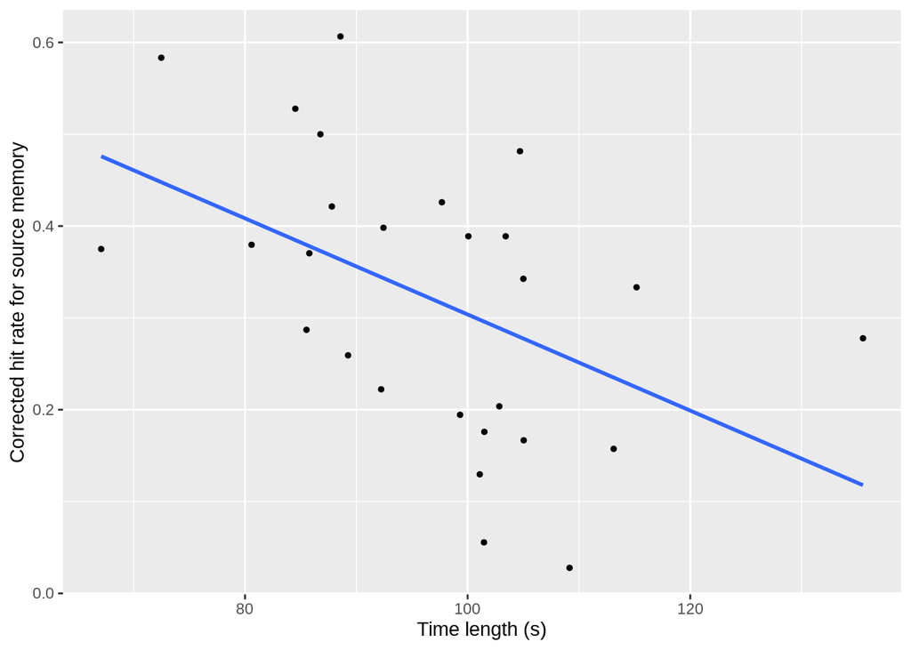

```
##             Model df        AIC       BIC   logLik   Test    L.Ratio p-value
## baseline        1  3 -10.890172 -1.838332 8.445086
## t.intercept     2  4  -8.969351  3.099768 8.484675 1 vs 2 0.07917901  0.7784
## t.slope         3  6  -4.967400 13.136279 8.483700 2 vs 3 0.00195093  0.9990
```

Nothing. No significant relationship!

## 4.2 Delayed version

### 4.2.1 Outside the rooms

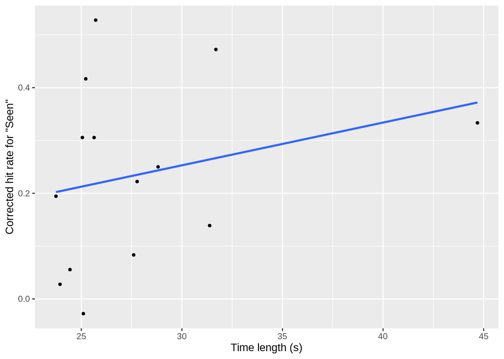

```r
baseline <- lme(SAcc ~ 1, random = ~ 1|SubjectNo, data = outside.per.room[Version == "Delayed" & !SubjectNo %in% c("P17", "P52")], method = "ML", control = list(msMaxIter = 500, opt = "optim", msVerbose=FALSE), na.action = na.exclude)

t.intercept <- update(baseline, .~. + Duration)
t.slope     <- update(t.intercept, random = ~ 1 + Duration|SubjectNo)

anova(baseline, t.intercept, t.slope)
```

```
##             Model df       AIC        BIC   logLik   Test  L.Ratio p-value
## baseline        1  3 -21.76997 -14.477525 13.88499
## t.intercept     2  4 -20.78163 -11.058362 14.39081 1 vs 2 1.011654  0.3145
## t.slope         3  6 -18.47124  -3.886335 15.23562 2 vs 3 1.689606  0.4296
```

#### 4.2.1.1 What about source memory?

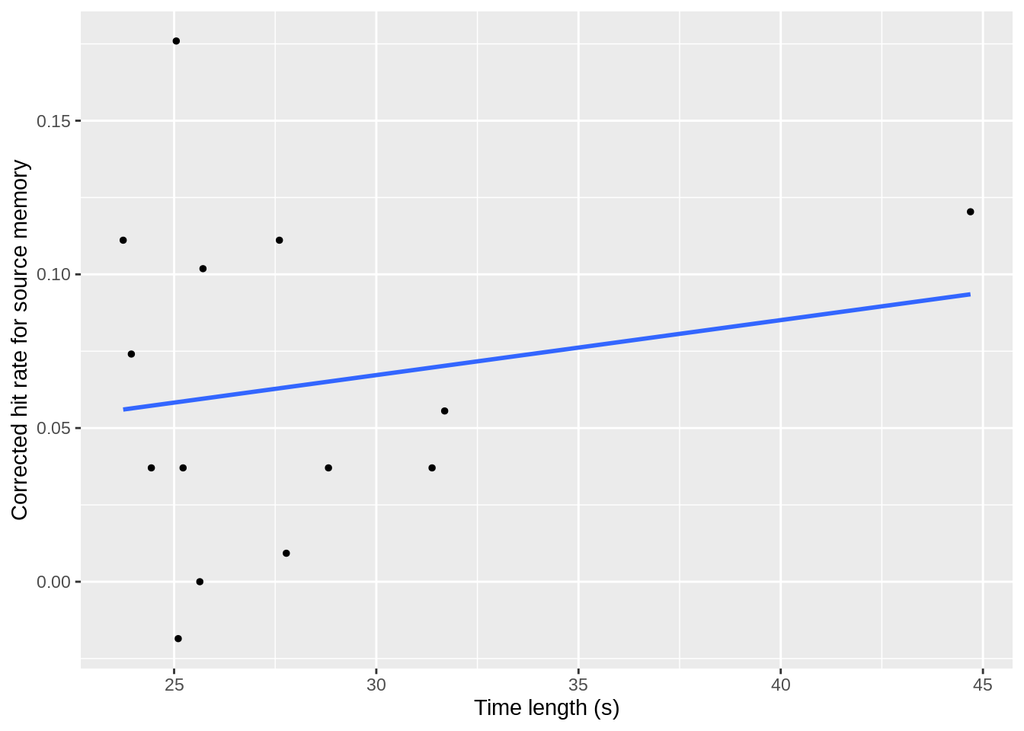

```
##             Model df       AIC       BIC   logLik   Test   L.Ratio p-value
## baseline        1  3 -46.89121 -39.59876 26.44561
## t.intercept     2  4 -46.83666 -37.11339 27.41833 1 vs 2 1.9454456  0.1631
## t.slope         3  6 -42.83834 -28.25344 27.41917 2 vs 3 0.0016856  0.9992
```

### 4.2.2 Inside the rooms

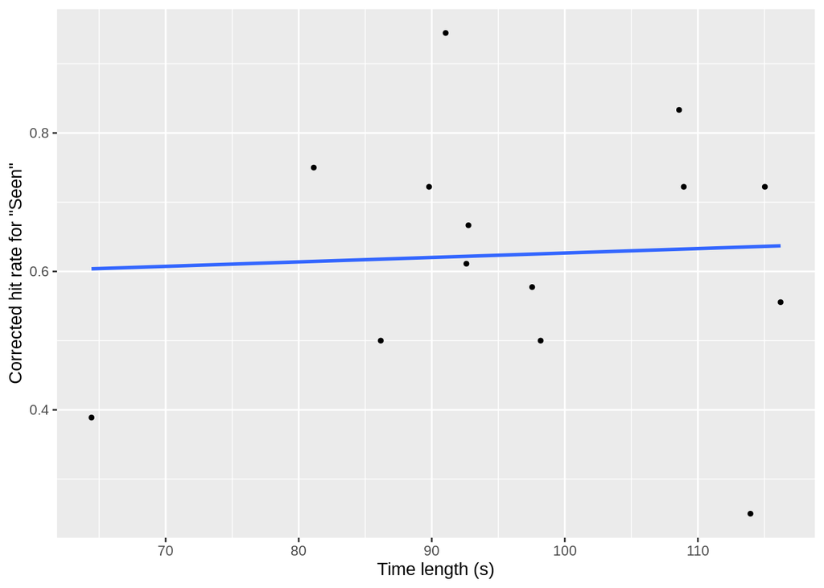

```r
baseline <- lme(SAcc ~ 1, random = ~ 1|SubjectNo, data = inside.per.room[Version == "Delayed" & !SubjectNo %in% c("P17", "P52")], method = "ML", control = list(msMaxIter = 500, opt = "optim", msVerbose=FALSE), na.action = na.exclude)

t.intercept <- update(baseline, .~. + Duration)
t.slope     <- update(t.intercept, random = ~ 1 + Duration|SubjectNo)

anova(baseline, t.intercept, t.slope)
```

```
##             Model df      AIC      BIC   logLik   Test   L.Ratio p-value
## baseline        1  3 0.945243  8.16540 2.527379
## t.intercept     2  4 2.847441 12.47432 2.576279 1 vs 2 0.0978014  0.7545
## t.slope         3  6 5.700946 20.14126 3.149527 2 vs 3 1.1464950  0.5637
```

#### 4.2.2.1 What about source memory?

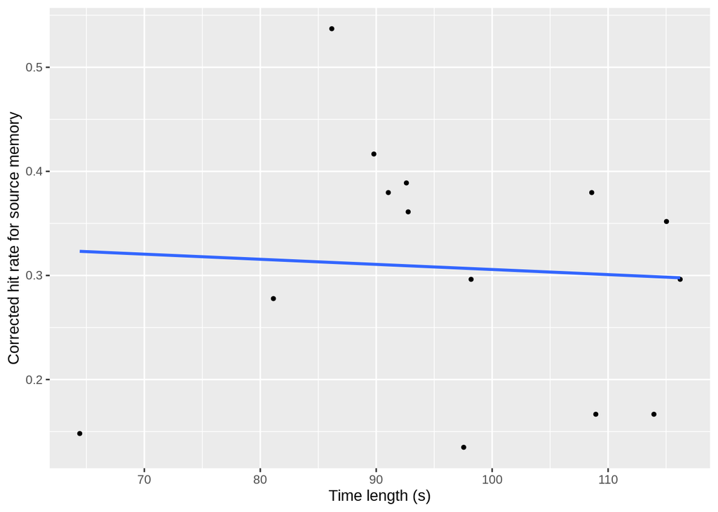

```
##             Model df       AIC        BIC   logLik   Test   L.Ratio p-value
## baseline        1  3 -25.32416 -18.104003 15.66208
## t.intercept     2  4 -23.48781 -13.860929 15.74390 1 vs 2 0.1636451  0.6858
## t.slope         3  6 -19.71041  -5.270099 15.85521 2 vs 3 0.2226089  0.8947
```